# Investigation of univariate analysis

Single-trait SNP clustering: each column is a GWAS SNP for the target trait, each row is a background study (phenotypic or molecular; no collapsing). Profiles are oriented, compressed, and clustered with **ebmf** (Louvain: signed modularity on the SNP similarity graph; EBMF: empirical Bayes matrix factorization with overlapping programs, hard-assigned to their strongest factor). Modules/programs are then validated with a filtering framework — internal coherence (mean internal similarity and connectedness), factor strength normalised by the square root of the number of filtered SNPs, and trait-subsampling stability — plus descriptive evidence scores (aggregate posterior evidence and factor distinctiveness) before interpretation.

We use **Type 2 Diabetes** (trait id `114`).

Active run parameters

| api | gpmap_url | min_snp_signals | trait_subset | cluster_type | louvain_gamma | compress_method | compress_scale | include_trans | include_situated_gene | min_specificity | similarity_threshold | ebmf_se_mode | ebmf_beta_scale | ebmf_lfsr_threshold | ebmf_prior | ebmf_backfit | ebmf_magnitude_threshold | min_mean_internal | min_connectedness | n_null | alpha_membership | n_candidate_tier | n_rep | frac_traits | stability_top_n | stability_threshold | posterior_stat | posterior_evidence_cap | redundancy_threshold | … |
| --- | --- | --- | --- | --- | --- | --- | --- | --- | --- | --- | --- | --- | --- | --- | --- | --- | --- | --- | --- | --- | --- | --- | --- | --- | --- | --- | --- | --- | --- | --- |
| local | http://localhost:8000 | 2 | phenotypic | ebmf | 1.5 | asinh | 5 | TRUE | FALSE | 1.25 | 0.2 | unit | trait | 0.02 | point_laplace | TRUE | 0.75 | 0.3 | 0.5 | 10 | 0.05 | 25 | 3 | 0.8 | 20 | 0.5 | median | 50 | 0.9 | … |

## Step 1: Pleiotropy matrix

`build_pleiotropy_matrix()` builds z-scores (`beta / se`) at each target SNP. With `associations = "coloc"` it uses colocalisation rows only; with `associations = "full"` it uses all full associations (`/associations-full`). Molecular QTL studies stay as their own rows. When `include_trans = FALSE`, trans target markers are removed from the association rows before the matrix is built.

Pleiotropy matrix summary

| trait | n_rows | n_phenotypic | n_molecular | n_snps | fraction_non_na |
| --- | --- | --- | --- | --- | --- |
| Type 2 diabetes | 3424 | 1027 | 2397 | 149 | 0.012 |

## Step 1.5: Filter sparse and ubiquitous traits

Drop rows with fewer than `min_snp_signals` non-`NA` values, or with non-`NA` fraction above `max_snp_fraction` (target trait kept).

After sparse / ubiquitous trait filter

| min_snp_signals | max_snp_fraction | n_sparse_traits_removed | n_ubiquitous_traits_removed | n_traits_after | n_snps |
| --- | --- | --- | --- | --- | --- |
| 2 | 0.8 | 2912 | 0 | 512 | 149 |

## Step 2: Orient and compress (X*)

## Step 3: SNP similarity (S)

Missing trait-SNP cells are treated as zero effects, preserving the original cosine similarity calculation.

SNP similarity summary

| n_snps | median_pairwise_overlap | fraction_pairs_eligible | min_similarity | max_similarity | mean_similarity |
| --- | --- | --- | --- | --- | --- |
| 149 | 1 | 1 | -0.91 | 1 | 0.26 |

## Step 4: Clustering

Edges with `|S| < similarity_threshold` are zeroed before Louvain. For EBMF, the oriented compressed matrix `X_star` is factorised directly (features x SNPs), a global mega-factor is dropped if detected, and each SNP is assigned to the factor with the largest absolute posterior loading among the factors it significantly belongs to.

## Step 4.5: Module / program validation

Both clustering paths share the same internal-coherence metrics, computed on the SNP similarity graph:

- **mean_internal_similarity** — mean off-diagonal `S` inside the module
- **separation** — internal minus external mean similarity
- **connectedness** — fraction of SNP pairs with `|S| >= similarity_threshold`

For EBMF, `summarise_ebmf_programs()` folds the graph-reliability metrics together with trait-subsampling **stability** and the descriptive **additional scores** into a single per-program table with pass/fail flags and an overall `status`:

- **factor_strength / factor_strength_per_snp** — proportion of observed matrix signal attributable to the factor (from its fitted reconstruction), computed on the lFSR/magnitude-filtered subset of EBMF-supported SNPs; `factor_strength_per_snp = factor_strength / sqrt(n_snps_filtered)`. Reported for context only; it does not gate `status`.
- **replication** — trait-subsampling stability: how often the top `stability_top_n` loading SNPs are recovered when `1 - frac_traits` of the traits are held out and flashier is refit (`n_rep` reruns, run in parallel on `cores` cores). Because this is expensive, it is only computed for programs that pass the internal-coherence checks; those programs must reach `replication >= stability_threshold`. Stability should use the same filtered SNP reference sets as the other program-level calculations, and the refitted programs are filtered with the same lFSR/magnitude thresholds.
- **posterior_evidence** — aggregate (`posterior_stat`) of `-log10(lfsr)` across assigned SNPs. Distinguishes programs dominated by borderline `lfsr ~ 0.05` memberships from programs whose memberships carry much stronger posterior sign evidence.
- **max_abs_factor_corr / redundant** — maximum absolute correlation of the program’s SNP loading vector with any other program; programs exceeding `redundancy_threshold` are flagged `redundant`.
- **max_pair_redundancy / most_redundant_program / redundancy_pass** — factor distinctiveness: for each program, the reciprocal SNP containment with every other program (`pair_redundancy = min(shared / n_snps_A, shared / n_snps_B)` on the assigned membership sets). The program fails (`redundancy_pass = FALSE`) when `max_pair_redundancy >= 0.9`, i.e. it captures essentially the same SNP set as another program.

A program is `valid` if it passes all four filters (`size`, `internal`, `stability`, `redundancy`); the failure reason is recorded in `status`.

All EBMF programs returned by flash, with each filter check. n_snps is the number of SNPs with nonzero EBMF support and n_snps_filtered is the subset surviving the lFSR/magnitude gate; factor_strength (as % of observed matrix signal) and factor_strength/sqrt(n_snps_filtered) are reported for context but do not gate status; replication is only checked for programs passing internal coherence (otherwise –); max_pair_redundancy is the reciprocal SNP containment with the most overlapping program (most_redundant_program), and redundancy_pass fails at >= 0.9; status is ‘valid’ or lists the failed checks (size; internal; stability; redundancy).

| program | n_snps | n_snps_filtered | mean_internal_similarity | connectedness | factor_strength_pct | factor_strength_per_snp_pct | replication | posterior_evidence | max_abs_factor_corr | redundant | max_pair_redundancy | most_redundant_program | redundancy_pass | size_pass | internal_pass | stability_pass | status |
| --- | --- | --- | --- | --- | --- | --- | --- | --- | --- | --- | --- | --- | --- | --- | --- | --- | --- |
| 2 | 149 | 32 | 0.351 | 0.685 | 7.34 | 1.297 | 0.75 | 38.76 | 0.639 | no | 0.312 | 9 | pass | pass | pass | pass | valid |
| 7 | 149 | 7 | 0.396 | 0.905 | 5.50 | 2.078 | 0.857 | 50.00 | 0.256 | no | 0.364 | 8 | pass | pass | pass | pass | valid |
| 9 | 149 | 20 | 0.472 | 0.868 | 4.27 | 0.956 | 0.9 | 50.00 | 0.353 | no | 0.312 | 2 | pass | pass | pass | pass | valid |
| 17 | 149 | 3 | 0.348 | 0.667 | 2.24 | 1.295 | 0.778 | 50.00 | 0.481 | no | 0.167 | 15 | pass | pass | pass | pass | valid |
| 19 | 149 | 3 | 0.330 | 1.000 | 1.14 | 0.658 | 0.667 | 4.22 | 0.084 | no | 0.333 | 24 | pass | pass | pass | pass | valid |
| 22 | 149 | 18 | 0.385 | 0.699 | 1.10 | 0.259 | 0.519 | 7.99 | 0.367 | no | 0.300 | 9 | pass | pass | pass | pass | valid |
| 27 | 149 | 4 | 0.542 | 1.000 | 1.02 | 0.508 | 0.75 | 26.09 | 0.367 | no | 0.250 | 20 | pass | pass | pass | pass | valid |
| 1 | 149 | 4 | 0.143 | 1.000 | 29.86 | 14.929 | – | 50.00 | 0.256 | no | 1.000 | 4 | fail | pass | fail | n/a (not checked) | internal_similarity; redundancy |
| 3 | 149 | 17 | 0.081 | 0.691 | 14.03 | 3.402 | – | 50.00 | 0.263 | no | 0.765 | 6 | pass | pass | fail | n/a (not checked) | internal_similarity |
| 4 | 149 | 4 | 0.143 | 1.000 | 13.09 | 6.546 | – | 50.00 | 0.409 | no | 1.000 | 1 | fail | pass | fail | n/a (not checked) | internal_similarity; redundancy |
| 6 | 149 | 16 | 0.039 | 0.458 | 8.20 | 2.049 | – | 50.00 | 0.409 | no | 0.765 | 3 | pass | pass | fail | n/a (not checked) | internal_similarity; connectedness |
| 8 | 149 | 11 | 0.214 | 0.527 | 5.23 | 1.578 | – | 49.23 | 0.365 | no | 0.364 | 7 | pass | pass | fail | n/a (not checked) | internal_similarity |
| 5 | 149 | 2 | 0.078 | 0.000 | 3.45 | 2.442 | – | 50.00 | 0.101 | no | 0.250 | 1 | pass | fail | fail | n/a (not checked) | size; internal_similarity; connectedness |
| 10 | 149 | 6 | 0.177 | 0.600 | 2.72 | 1.108 | – | 50.00 | 0.389 | no | 0.333 | 1 | pass | pass | fail | n/a (not checked) | internal_similarity |
| 14 | 149 | 2 | 0.311 | 1.000 | 2.39 | 1.692 | – | 27.46 | 0.184 | no | 0.100 | 9 | pass | fail | fail | n/a (not checked) | size |
| 18 | 149 | 2 | 0.751 | 1.000 | 2.28 | 1.610 | – | 50.00 | 0.191 | no | 0.500 | 1 | pass | fail | fail | n/a (not checked) | size |
| 13 | 149 | 4 | 0.277 | 0.833 | 1.64 | 0.818 | – | 8.21 | 0.066 | no | 0.143 | 7 | pass | pass | fail | n/a (not checked) | internal_similarity |
| 16 | 149 | 1 | NA | NA | 1.61 | 1.607 | – | 50.00 | 0.048 | no | 0.000 | 1 | pass | fail | fail | n/a (not checked) | size; internal_similarity; connectedness |
| 25 | 149 | 7 | 0.099 | 0.381 | 1.55 | 0.586 | – | 50.00 | 0.562 | no | 0.294 | 3 | pass | pass | fail | n/a (not checked) | internal_similarity; connectedness |
| 12 | 149 | 3 | 0.090 | 0.333 | 1.42 | 0.822 | – | 6.65 | 0.140 | no | 0.333 | 21 | pass | pass | fail | n/a (not checked) | internal_similarity; connectedness |
| 21 | 149 | 2 | 0.216 | 1.000 | 1.33 | 0.940 | – | 30.18 | 0.076 | no | 0.333 | 12 | pass | fail | fail | n/a (not checked) | size; internal_similarity |
| 15 | 149 | 6 | 0.105 | 0.400 | 1.06 | 0.434 | – | 50.00 | 0.269 | no | 0.333 | 10 | pass | pass | fail | n/a (not checked) | internal_similarity; connectedness |
| 20 | 149 | 4 | 0.084 | 0.167 | 1.06 | 0.532 | – | 4.37 | 0.092 | no | 0.250 | 1 | pass | pass | fail | n/a (not checked) | internal_similarity; connectedness |
| 26 | 149 | 1 | NA | NA | 1.00 | 1.003 | – | 50.00 | 0.562 | no | 0.167 | 10 | pass | fail | fail | n/a (not checked) | size; internal_similarity; connectedness |
| 24 | 149 | 3 | 0.234 | 1.000 | 0.99 | 0.573 | – | 14.84 | 0.160 | no | 0.333 | 12 | pass | pass | fail | n/a (not checked) | internal_similarity |
| 23 | 149 | 4 | 0.236 | 0.500 | 0.70 | 0.352 | – | 24.36 | 0.252 | no | 0.250 | 27 | pass | pass | fail | n/a (not checked) | internal_similarity |
| 11 | 149 | 25 | 0.309 | 0.543 | 0.68 | 0.135 | 0.383 | 6.43 | 0.639 | no | 0.240 | 9 | pass | pass | pass | fail | stability |

EBMF program validation summary (factor strength is reported but does not gate status). n_unique_snps counts each SNP once even when it belongs to multiple programs (all = across all programs, valid = across valid programs only); n_fail_redundancy counts programs with reciprocal SNP containment >= 0.9; pct_of_total_snps is relative to the trait’s 149 SNPs.

| n_programs | n_valid | n_fail_size | n_fail_internal | n_fail_stability | n_fail_redundancy | n_redundant | n_unique_snps_all | n_unique_snps_valid | pct_of_total_snps_all | pct_of_total_snps_valid |
| --- | --- | --- | --- | --- | --- | --- | --- | --- | --- | --- |
| 27 | 7 | 6 | 19 | 1 | 2 | 0 | 88 | 52 | 59.1 | 34.9 |

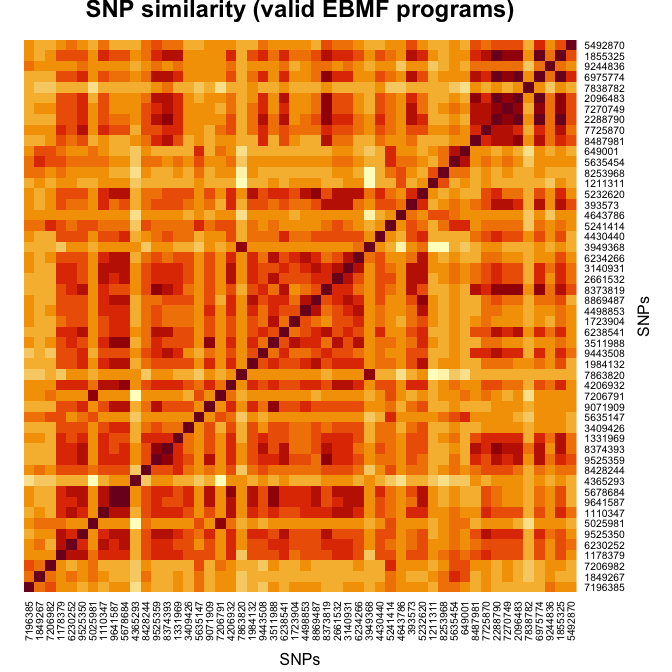

### Program overlap

Because EBMF programs are soft, the same SNP can belong to several programs. The UpSet plot below shows all valid programs, and for every observed intersection how many SNPs are shared by exactly that combination (a Venn diagram generalised to any number of programs). The left-hand bar chart is each program’s size; the dot matrix marks which programs each intersection involves.

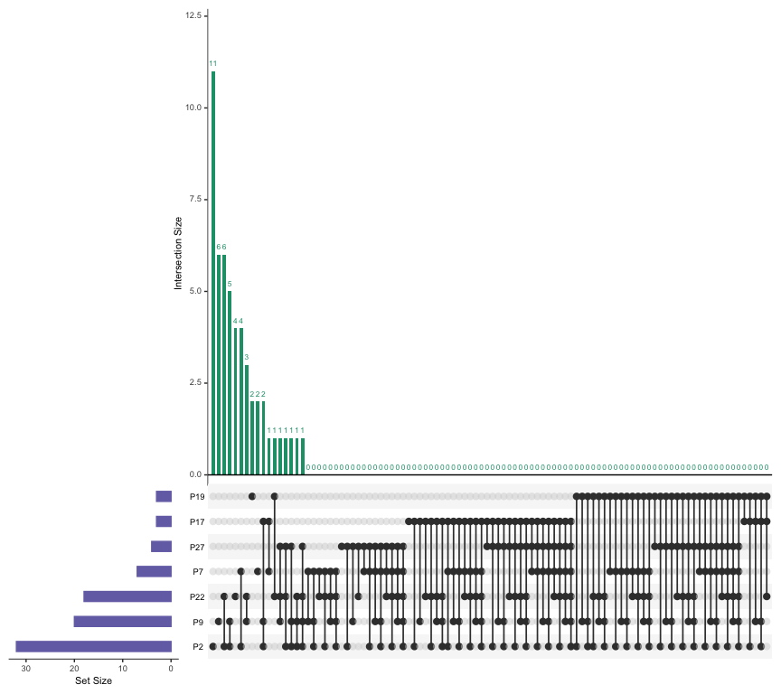

## Step 5: Interpret reliable modules

For each reliable module, rank background traits by **module specificity vs the rest of the trait** (`summarise_module_specific_traits()`), then summarise **trait-category and tissue enrichments vs the trait baseline**, plus pathway hits. `specificity = mean |z| in the module / (mean |z| in the rest + 0.1)` and `abs_mean_z_delta = module - rest` highlight traits that are specifically elevated in this module rather than merely large everywhere (which ranking by `abs_mean_z` alone would over-emphasise). Pathway enrichment is queried across Reactome, KEGG, and Human Phenotype Ontology (HP) with a separate call per source: Reactome and KEGG hits are reported side by side as **pathways**, and HP terms as **phenotypes**, so the three never compete for the same headline.

Trait baseline = all SNPs attributed to this trait in the clustering analysis (`colnames(S)`; for Louvain this equals `names(clusters$cluster)`, and for EBMF it is kept identical so both methods are annotated against the same baseline), using coloc rows for those SNPs only—not the whole GPMap universe. Each module is compared to the **rest of the trait** (leave-one-out): observed link share vs expected share, with fold enrichment.

Annotation tables show the top elevated categories/tissues even when FDR is not significant; FDR is reported when it passes 0.05.

Each hit is scored with a BH-corrected significance summary, thresholded at 0.05:

- **FDR** — hypergeometric test of the module vs the rest of the trait.

The bootstrap `CI` for the fold enrichment shows how precisely the ratio is estimated; because modules are small, a big ratio built on a few links carries a wide interval that includes 1 (the null), so read the CI together with the FDR rather than alone.

### Overview of significant annotations across modules

Top 6 module-specific traits and all significant category, tissue, pathway (Reactome and KEGG separately) and phenotype (HP) hits; n_snps = SNPs in the program, n_unique_snps = SNPs not present in any other program; trait values are specificity scores, and FDR is the BH-corrected hypergeometric enrichment (threshold 0.05)

[output not shown]

### Module 17 (3 SNPs)

Module annotations (enrichment vs trait baseline)

| module | trait_categories | tissues | reactome | kegg | phenotypes |
| --- | --- | --- | --- | --- | --- |
| Module 17 (3 SNPs) | **Disease Of Eye And Adnexa** (obs=11%, exp=1%, FE=21, CI=[0,86], FDR=0.0205) Disease Of Genitourinary System (obs=6%, exp=1%, FE=7.2, CI=[0,43]) Environmental Measures (obs=6%, exp=1%, FE=7.2, CI=[0,… | Artery Aorta (obs=13%, exp=2%, FE=6, CI=[0,16]) Liver (obs=7%, exp=1%, FE=6, CI=[0,24]) Stomach (obs=7%, exp=1%, FE=6, CI=[0,22]) | none | Adherens junction (FDR=0.0138) Hepatocellular carcinoma (FDR=0.0141) Gastric cancer (FDR=0.0141) | none |

Module-specific traits (specificity >= 1.25; module mean |z| / (rest mean |z| + 0.1))

| trait_name | trait_category | abs_mean_z | abs_mean_z_delta | specificity | mean_z |
| --- | --- | --- | --- | --- | --- |
| Haemoglobin A1c levels | Physiological Measures | 9.438 | 2.409 | 1.32 | 9.438 |

### Module 19 (3 SNPs)

Module annotations (enrichment vs trait baseline)

| module | trait_categories | tissues | reactome | kegg | phenotypes |
| --- | --- | --- | --- | --- | --- |
| Module 19 (3 SNPs) | Disease Of Circulatory System (obs=20%, exp=5%, FE=4, CI=[0,11]) Anthropometric Measures (obs=20%, exp=13%, FE=1.5, CI=[0,3.9]) Physiological Measures (obs=30%, exp=25%, FE=1.2, CI=[0,2.5]) | Skin Not Sun Exposed Suprapubic (obs=14%, exp=2%, FE=7.5, CI=[0,25]) Cells Cultured fibroblasts (obs=14%, exp=2%, FE=6.8, CI=[0,24]) Skin Sun Exposed Lower leg (obs=14%, exp=2%, FE=6.2, CI=[0,20]) | none | none | none |

No traits passed the module-specificity cutoff (specificity >= 1.25).

### Module 2 (32 SNPs)

Module annotations (enrichment vs trait baseline)

| module | trait_categories | tissues | reactome | kegg | phenotypes |
| --- | --- | --- | --- | --- | --- |
| Module 2 (32 SNPs) | **Disease Of Genitourinary System** (obs=3%, exp=0%, FE=8, CI=[0,16], FDR=0) **Environmental Measures** (obs=3%, exp=0%, FE=8, CI=[0,16], FDR=0) Infectious Disease (obs=1%, exp=0%, FE=2.7, CI=[0,8]) | Bladder (obs=1%, exp=0%, FE=2.6, CI=[0,10]) Plasma (obs=11%, exp=5%, FE=2, CI=[1.2,3.2]) Artery Aorta (obs=4%, exp=2%, FE=1.7, CI=[0.47,3.9]) | Intrinsic Pathway of Fibrin Clot Formation (FDR=0.0018) Removal of aminoterminal propeptides from gamma-carboxylated proteins (FDR=0.00593) Gamma-carboxylation, transport, and amino-terminal cleavage … | Complement and coagulation cascades (FDR=3.08e-13) Pancreatic secretion (FDR=0.00376) Protein digestion and absorption (FDR=0.0124) | none |

Module-specific traits (specificity >= 1.25; module mean |z| / (rest mean |z| + 0.1))

| trait_name | trait_category | abs_mean_z | abs_mean_z_delta | specificity | mean_z |
| --- | --- | --- | --- | --- | --- |
| Ratio of polyunsaturated fatty acids to monounsaturated fatty acids | Physiological Measures | 7.778 | 7.778 | 77.78 | -0.341 |
| Ratio of polyunsaturated fatty acids to total fatty acids | Physiological Measures | 7.597 | 7.597 | 75.97 | -0.258 |
| Triglyceride levels in HDL | Physiological Measures | 7.281 | 7.281 | 72.81 | -0.245 |
| Triglyceride levels in medium HDL | Physiological Measures | 7.182 | 7.182 | 71.82 | -0.299 |
| Monounsaturated fatty acid levels | Physiological Measures | 7.181 | 7.181 | 71.81 | -0.745 |
| Triglycerides to total lipids ratio in large LDL | Physiological Measures | 7.121 | 7.121 | 71.21 | 0.844 |
| Triglycerides to total lipids ratio in medium LDL | Physiological Measures | 6.809 | 6.809 | 68.09 | 0.645 |
| Cholesterol to total lipids ratio in IDL | Physiological Measures | 6.745 | 6.745 | 67.45 | -0.686 |
| Non-cancer illness code, self-reported: high cholesterol | Metabolic Disease | 6.651 | 6.651 | 66.51 | 0.667 |
| Free cholesterol to total lipids ratio in large HDL | Physiological Measures | 6.397 | 6.397 | 63.97 | -0.633 |

### Module 22 (18 SNPs)

Module annotations (enrichment vs trait baseline)

| module | trait_categories | tissues | reactome | kegg | phenotypes |
| --- | --- | --- | --- | --- | --- |
| Module 22 (18 SNPs) | Disease Of Musculoskeletal System And Connective Tissue (obs=2%, exp=1%, FE=3.6, CI=[0,22]) Physiological Measures (obs=35%, exp=24%, FE=1.5, CI=[0.89,2.2]) Anthropometric Measures (obs=16%, exp=13%, … | Bladder (obs=1%, exp=0%, FE=3.5, CI=[0,14]) Pituitary (obs=3%, exp=1%, FE=2.2, CI=[0.44,5.6]) Uterus (obs=2%, exp=1%, FE=2, CI=[0,8.4]) | none | none | none |

No traits passed the module-specificity cutoff (specificity >= 1.25).

### Module 27 (4 SNPs)

Module annotations (enrichment vs trait baseline)

| module | trait_categories | tissues | reactome | kegg | phenotypes |
| --- | --- | --- | --- | --- | --- |
| Module 27 (4 SNPs) | Disease Of Musculoskeletal System And Connective Tissue (obs=6%, exp=1%, FE=12, CI=[0,49]) Disease Of Skin And Subcutaneous Tissue (obs=6%, exp=2%, FE=4.1, CI=[0,24]) Reproductive Measures (obs=6%, ex… | Colon Transverse (obs=12%, exp=2%, FE=6.8, CI=[0,21]) Small Intestine Terminal Ileum (obs=6%, exp=1%, FE=5.3, CI=[0,22]) Esophagus Gastroesophageal Junction (obs=6%, exp=2%, FE=3.9, CI=[0,16]) | none | Autoimmune thyroid disease (FDR=0.0193) | none |

Module-specific traits (specificity >= 1.25; module mean |z| / (rest mean |z| + 0.1))

| trait_name | trait_category | abs_mean_z | abs_mean_z_delta | specificity | mean_z |
| --- | --- | --- | --- | --- | --- |
| Medication use (drugs used in diabetes) | Metabolic Disease | 8.306 | 2.602 | 1.43 | 8.306 |
| Glycated haemoglobin HbA1c levels (UKB data field 30750) | Physiological Measures | 8.873 | 2.412 | 1.35 | 8.873 |

### Module 7 (7 SNPs)

Module annotations (enrichment vs trait baseline)

| module | trait_categories | tissues | reactome | kegg | phenotypes |
| --- | --- | --- | --- | --- | --- |
| Module 7 (7 SNPs) | Disease Of Digestive System (obs=7%, exp=2%, FE=3.8, CI=[0,18]) Reproductive Measures (obs=7%, exp=3%, FE=2.7, CI=[0,9]) Anthropometric Measures (obs=25%, exp=13%, FE=2, CI=[0.81,3.6]) | Kidney Cortex (obs=3%, exp=1%, FE=4.8, CI=[0,22]) **Plasma** (obs=24%, exp=6%, FE=4.1, CI=[1.6,7.4], FDR=0.0177) Esophagus Mucosa (obs=7%, exp=2%, FE=3.5, CI=[0,10]) | Triglyceride catabolism (FDR=0.0315) Transcriptional regulation of white adipocyte differentiation (FDR=0.0315) Growth hormone receptor signaling (FDR=0.0315) | PPAR signaling pathway (FDR=0.000727) | none |

Module-specific traits (specificity >= 1.25; module mean |z| / (rest mean |z| + 0.1))

| trait_name | trait_category | abs_mean_z | abs_mean_z_delta | specificity | mean_z |
| --- | --- | --- | --- | --- | --- |
| Glycine levels | Physiological Measures | 4.708 | 4.708 | 47.08 | -4.708 |
| HDL cholesterol levels | Physiological Measures | 9.101 | 3.396 | 1.57 | -9.101 |
| Impedance of arm (right) | Physiological Measures | 8.280 | 2.373 | 1.38 | -8.280 |
| Waist-hip ratio | Anthropometric Measures | 8.514 | 2.301 | 1.35 | 4.186 |
| Impedance of arm (left) | Physiological Measures | 8.102 | 2.193 | 1.35 | -8.102 |
| Waist-to-hip ratio adjusted for BMI | Anthropometric Measures | 8.505 | 2.248 | 1.34 | 4.178 |
| Sex hormone-binding globulin levels | Physiological Measures | 8.373 | 1.945 | 1.28 | -8.373 |
| Triglyceride levels (UKB data field 30870) | Physiological Measures | 7.152 | 1.664 | 1.28 | 7.152 |
| Sex hormone-binding globulin levels adjusted for BMI | Physiological Measures | 8.470 | 1.938 | 1.28 | -8.470 |
| Fasting insulin | Physiological Measures | 6.604 | 1.459 | 1.26 | 6.604 |

### Module 9 (20 SNPs)

Module annotations (enrichment vs trait baseline)

| module | trait_categories | tissues | reactome | kegg | phenotypes |
| --- | --- | --- | --- | --- | --- |
| Module 9 (20 SNPs) | **Disease Of Eye And Adnexa** (obs=4%, exp=0%, FE=14, CI=[0,29], FDR=0) Disease Of Genitourinary System (obs=3%, exp=1%, FE=4.8, CI=[0,19]) Environmental Measures (obs=3%, exp=1%, FE=4.8, CI=[0,19]) | Bladder (obs=1%, exp=0%, FE=3.9, CI=[0,16]) Pancreas (obs=3%, exp=1%, FE=2.6, CI=[0,7.8]) Artery Aorta (obs=4%, exp=2%, FE=2, CI=[0.43,4.7]) | none | none | none |

Module-specific traits (specificity >= 1.25; module mean |z| / (rest mean |z| + 0.1))

| trait_name | trait_category | abs_mean_z | abs_mean_z_delta | specificity | mean_z |
| --- | --- | --- | --- | --- | --- |
| TSHB Plasma pQTL | NA | 5.676 | 5.676 | 56.76 | -2.405 |
| Peak expiratory flow | Physiological Measures | 5.239 | 5.239 | 52.39 | -5.239 |
| Glycated haemoglobin levels | Physiological Measures | 6.418 | 2.481 | 1.59 | 6.418 |
| Hematocrit | Physiological Measures | 7.789 | 2.679 | 1.50 | -2.450 |
| Haemoglobin A1c levels | Physiological Measures | 8.785 | 2.834 | 1.45 | 8.785 |
| Haemoglobin concentration | Physiological Measures | 7.671 | 2.208 | 1.38 | -2.308 |
| Red blood cell count | Physiological Measures | 6.967 | 1.979 | 1.37 | -2.655 |
| Glycated haemoglobin HbA1c levels (UKB data field 30750) | Physiological Measures | 7.965 | 2.103 | 1.34 | 7.965 |
| Illnesses of father: Diabetes | Metabolic Disease | 6.623 | 1.682 | 1.31 | 6.623 |
| Type 2 diabetes (Firth correction) | Metabolic Disease | 6.631 | 1.653 | 1.31 | 6.631 |

## Step 6: Pleiotropy of program-unique vs shared SNPs

Because EBMF programs are soft, a SNP can be assigned to exactly one valid program (**unique**) or to several (**shared**). If programs capture distinct biological programmes, SNPs that uniquely define a single program should be more specific — i.e. carry a lower pleiotropy score (fewer distinct trait categories and protein-coding genes via coloc groups) than SNPs whose signal is shared across programs. We test that here with `get_all_variant_pleiotropies()`.

```
#>
#>
#> Table: Pleiotropy of program-unique vs shared SNPs across valid programs (n = 52 SNPs)
#>
#> |membership_class |metric                                                  | n_snps| mean_pleiotropy| median_pleiotropy|
#> |:----------------|:-------------------------------------------------------|------:|---------------:|-----------------:|
#> |unique           |gene pleiotropy (distinct genes per SNP)                |     25|           32.04|                 1|
#> |unique           |trait-category pleiotropy (distinct categories per SNP) |     25|            3.40|                 3|
#> |shared           |gene pleiotropy (distinct genes per SNP)                |     27|            3.63|                 2|
#> |shared           |trait-category pleiotropy (distinct categories per SNP) |     27|            3.37|                 3|
#>
#>
#> Table: Wilcoxon rank-sum test comparing pleiotropy of unique vs shared SNPs
#>
#> |metric                                                  | wilcoxon_p|
#> |:-------------------------------------------------------|----------:|
#> |trait-category pleiotropy (distinct categories per SNP) |      0.828|
#> |gene pleiotropy (distinct genes per SNP)                |      0.520|
```

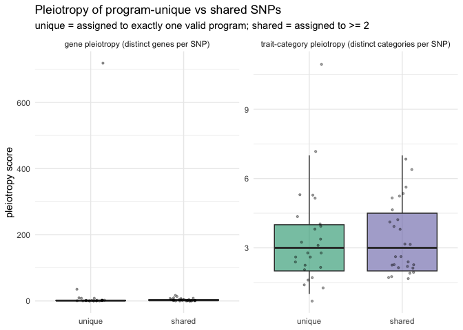